# Assignment 2 Report

Taylor Falk

11/17/2021

**Please read this brief introduction to R Markdown, and complete the second half of the document yourself.**

# R Markdown

R Markdown, `.Rmd` files, are a type of markdown files that can execute R code in an R environment. Markdown is an open source language used for easily creating documents such as web pages and PDFs. Markdown and R Markdown can be used to procedurally generate documents and reports, which have a wide number of use-cases across bioinformatics. Not only can you save time by creating code to automatically draft documents, you can also include detailed instructions and information alongside your code.

## knitr

`knitr` is simply the package R uses to convert the R Markdown into the appropriate output (HTML, PDF, or Word). While there is a deep level of customization available, most users can comfortably create beautiful documents with the default parameters. In order to compile your markdown, in RStudio you can select the `Knit` button below the open file button.

## Markdown Basics

The raw markdown, which you may or may not be looking at, is styled very basically. The largest titles start with one octothorpe `#`. The more `#`’s added, the smaller a title or header becomes.

# Biggest

## 2nd Biggest

### so on

#### and so forth

##### until you have

###### six octothorpes

then nothing happens.

Importantly, two spaces () can be included after a line of text to start a new line.

Markdown can be styled a few different ways:  
`_italics_` -> *italics*  
`**bold**` -> **bold**  
`` `monospace` `` -> `monospace`, good for code

A good cheat sheet is the [Markdown Guide Cheat Sheet](https://www.markdownguide.org/cheat-sheet)

## R Code in Markdown

The really vital part of R Markdown is the inclusion of code snippets you can place into the document, which will run and print out to users. In this snippet I create a function that says hello and that text is printed inside the document.

```r
say_hi <- function() {
  return("Hello world.")
}
print(say_hi())
```

```
## [1] "Hello world."
```

The syntax of the **snippet* is simple, with three back ticks `` ``` `` indicating the start and end of the snippet, and a lower case `r` in curly braces `{}` to indicate what language is used: `{r}` indicates R, `{python}` indicates Python. R Markdown does not support every language, but there are use cases where one document running both R and Python code can prove extremely useful and concise. There is also a button in RStudio to insert a snippet, it is a small green `+C` in the top right of the editor.

```python
import datetime
print(f'Wishing you a wonderful hello from Python at {datetime.datetime.now()}')
```

```
## Wishing you a wonderful hello from Python at 2023-10-04 00:25:21.269764
```

I can also test my code in RStudio without having to knit the entire document by pressing the green “Play” arrow on the snippet I am interested in.

Finally, R Markdown scripts can `source()` other `.R` scripts and use them in their execution environment. This mean I can define a function in my `main.R` script and use it in my R Markdown snippets. Note that the converse is true, using `knitr::purl()`, and the code established in an R Markdown can be sourced, and *tested*, using an normal `.R` script.

Also note that the environment is carried from one snippet to another, so if I define a function or load a file in one snippet I can use those objects in later snippets.

```r
message <- 'The last example...for now.'
```

```r
print(paste(message, 'But there\'s always room for more.'))
```

```
## [1] "The last example...for now. But there's always room for more."
```

# Assignment

Using what you know from this document and the `main.R` script, use the functions from `main.R` to draw a boxplot of expression levels. Use this R Markdown document to describe your code as you are using it in this document, as done above. Take time to enhance your ggplot function from the `main.R` script with high quality visual aesthetics. Do not use default ggplot colors.

```r
# use source to load your functions from main.R into this document.
source("main.R")
```

```
## Bioconductor version '3.15' is out-of-date; the current release version '3.17'
##   is available with R version '4.3'; see https://bioconductor.org/install
```

```r
library(tidyverse)
```

## Loading CSV with `load_expression()`

Importing data into R effectively is crucial. For our tasks, we prefer the tibble format, a modern representation of data frames in R. Load the data into a tibble as we have done in prior assignments.

```r
# Load the expression data
result_tib <- load_expression("data/example_intensity_data_subset.csv")
result_tib # Display the initial rows of the data
```

```
## # A tibble: 1,000 × 36
##    probe   GSM972389 GSM972390 GSM972396 GSM972401 GSM972409 GSM972412 GSM972413
##    <chr>       <dbl>     <dbl>     <dbl>     <dbl>     <dbl>     <dbl>     <dbl>
##  1 242413…      4.41      4.23      4.54      4.17      4.45      4.74      4.57
##  2 155640…      2.89      2.85      2.89      2.94      2.93      2.91      2.76
##  3 220640…      4.12      3.77      3.98      3.62      3.64      4.39      4.24
##  4 220425…      3.33      3.87      3.65      3.51      3.46      3.42      3.76
##  5 228274…      6.57      7.00      6.59      6.52      6.81      6.38      5.71
##  6 155605…      4.89      2.41      4.79      3.46      3.92      5.43      4.37
##  7 236154…      3.07      3.48      2.81      4.19      3.12      3.07      4.57
##  8 237185…      4.11      4.31      4.39      3.71      4.06      4.81      3.86
##  9 229683…      3.49      3.71      3.78      3.60      3.35      4.06      3.76
## 10 157011…      2.87      2.86      2.60      2.51      2.82      2.62      2.55
## # … with 990 more rows, and 28 more variables: GSM972422 <dbl>,
## #   GSM972429 <dbl>, GSM972433 <dbl>, GSM972438 <dbl>, GSM972440 <dbl>,
## #   GSM972443 <dbl>, GSM972444 <dbl>, GSM972446 <dbl>, GSM972453 <dbl>,
## #   GSM972457 <dbl>, GSM972459 <dbl>, GSM972463 <dbl>, GSM972467 <dbl>,
## #   GSM972472 <dbl>, GSM972473 <dbl>, GSM972475 <dbl>, GSM972476 <dbl>,
## #   GSM972477 <dbl>, GSM972479 <dbl>, GSM972480 <dbl>, GSM972487 <dbl>,
## #   GSM972488 <dbl>, GSM972489 <dbl>, GSM972496 <dbl>, GSM972502 <dbl>, …
```

## Filtering Rows with `filter_15()`

To effectively work with our slightly vast dataset, it’s essential to filter out rows that don’t meet certain criteria. The `filter_15()` function does precisely this by retaining rows where at least 15% of the values surpass a log2(15) expression level—equivalent to approximately 3.9. Notably, the function returns only the probe IDs, providing a summarized view of the dataset that meets the criteria.

While one might initially consider using traditional loops for row-wise operations, such methods can be inefficient for large datasets. Leveraging functions from the Tidyverse, particularly from the `dplyr` package, offers a more efficient and readable approach. Functions like `filter()` and `mutate()` allow for swift data transformations, enhancing both clarity and performance.

```r
filtered_probes <- c(filter_15(result_tib)$probe)
```

```
## [1] "Probes remaining in filtered dataset: 701"
```

```r
print(paste0("Original number of probes in unfiltered data: ", nrow(result_tib)))
```

```
## [1] "Original number of probes in unfiltered data: 1000"
```

```r
print(paste0("Probes remaining in filtered dataset: ", length(filtered_probes)))
```

```
## [1] "Probes remaining in filtered dataset: 701"
```

```r
#tibble of probes that survive the filter
filter_15(result_tib)
```

```
## [1] "Probes remaining in filtered dataset: 701"
```

```
## # A tibble: 701 × 1
## # Rowwise:
##    probe
##    <chr>
##  1 242413_at
##  2 220640_at
##  3 228274_at
##  4 1556054_at
##  5 237185_at
##  6 229683_s_at
##  7 242882_at
##  8 222032_s_at
##  9 204735_at
## 10 205732_s_at
## # … with 691 more rows
```

## Converting Affy IDs to HGNC Names: `affy_to_hgnc()`

Gene data often involves various identifiers, and converting between these can be crucial for data integration. The function `affy_to_hgnc()` serves this purpose by linking Affymetrix probe IDs to HGNC gene IDs using the `biomaRt` package. However, while `biomaRt` offers a direct connection to Ensembl, a comprehensive genomic database, its reliance on external APIs can lead to occasional connectivity issues. If errors arise during usage, they’re often due to these external connections rather than the code itself.

When implementing, remember:

- Use the `ENSEMBL_MART_ENSEMBL` biomart and the `hsapiens_gene_ensembl` dataset.
- Fetch the attributes `"affy_hg_u133_plus_2"` and `"hgnc_symbol"`.
- Despite the function aiming to return a tibble, `biomaRt`’s `getBM()` only deals with data.frames. Utilize `dplyr::pull()` to transform a tibble to a character vector, and `dplyr::as_tibble()` for converting a data frame back to a tibble.

```r
# Converting a sample affy ID to HGNC
filter_15(result_tib) %>% affy_to_hgnc() -> gene_names
```

```
## [1] "Probes remaining in filtered dataset: 701"
```

```r
gene_names
```

```
##           affy_hg_u133_plus_2    hgnc_symbol
## 1                 210408_s_at          CPNE6
## 2                 216389_s_at         DCAF11
## 3                 206574_s_at         PTP4A3
## 4                   223106_at        TMEM14C
## 5                   224578_at           RCC2
## 6                   211074_at
## 7                   202239_at          PARP4
## 8                 211765_x_at        PPIAP22
## 9                   213164_at         SLC5A3
## 10                  229829_at      LINC00526
## 11               1554339_a_at           COG3
## 12               1555613_a_at          ZAP70
## 13                209081_s_at
## 14                  220180_at         CCDC68
```

[output cut: 652 more lines]

## Refining Data with reduce_data()

Our data preparation’s ultimate goal is to streamline the dataset, focusing on relevant genes to make visualization more efficient with ggplot from the tidyverse package. The reduce_data() function serves this purpose by integrating various inputs, such as:

The original expression data. Probe IDs linked to HGNC symbols. Lists of ‘good’ and ‘bad’ gene names. The function operates as follows:

- Matches probe IDs with HGNC symbols using the base function match().
- Introduces the new data at the appropriate position using tibble::add_column().
- Segregates the genes into two categories, ‘good’ and ‘bad’, leveraging the which() function and the %in% operator.

In the end, the output is a tibble streamlined to only the genes of interest, with a dedicated column indicating the gene’s category.

```r
# Sample data and gene lists
goodGenes <- c("SLC1A4", "MGAT5B", "LINC02907", "BRIP1", "NRIP1", "TGDS", "PSMD10")
badGenes <- c("MAF", "PLD4", "LIG3", "RARA", "NOTCH4", "USP8", "RARG")

# Applying the function
reduced_data <- reduce_data(result_tib, gene_names, goodGenes, badGenes)
reduced_data
```

```
## # A tibble: 15 × 38
##    probe  hgnc_symbol gene_set GSM972389 GSM972390 GSM972396 GSM972401 GSM972409
##    <chr>  <chr>       <chr>        <dbl>     <dbl>     <dbl>     <dbl>     <dbl>
##  1 20260… NRIP1       good          9.61      7.01      9.55      7.38      8.61
##  2 20259… NRIP1       good          9.08      7.77      9.23      8.24      7.96
##  3 20934… MAF         bad           7.98      7.27      6.32      8.80      9.62
##  4 15545… PSMD10      good          8.81      7.88      8.55      8.47      9.12
##  5 15539… LINC02907   good          4.59      4.65      4.70      4.46      4.75
##  6 15664… PLD4        bad           4.23      4.87      4.35      4.37      4.68
##  7 23560… BRIP1       good          6.29      4.79      6.00      5.74      4.79
##  8 23844… MGAT5B      good          5.26      5.97      5.34      5.02      4.96
##  9 22986… LIG3        bad           6.71      5.22      5.95      5.21      5.84
## 10 21630… RARA        bad           5.83      6.46      6.05      6.70      6.23
## 11 20418… RARG        bad           6.35      7.46      6.88      6.88      7.10
## 12 24078… NOTCH4      bad           4.72      5.09      4.89      4.74      4.70
## 13 20824… TGDS        good          8.22      6.74      7.31      7.18      7.18
## 14 22950… USP8        bad           6.52      5.37      6.75      6.49      5.38
## 15 24437… SLC1A4      good          4.40      3.84      4.36      4.15      4.14
## # … with 30 more variables: GSM972412 <dbl>, GSM972413 <dbl>, GSM972422 <dbl>,
## #   GSM972429 <dbl>, GSM972433 <dbl>, GSM972438 <dbl>, GSM972440 <dbl>,
## #   GSM972443 <dbl>, GSM972444 <dbl>, GSM972446 <dbl>, GSM972453 <dbl>,
## #   GSM972457 <dbl>, GSM972459 <dbl>, GSM972463 <dbl>, GSM972467 <dbl>,
## #   GSM972472 <dbl>, GSM972473 <dbl>, GSM972475 <dbl>, GSM972476 <dbl>,
## #   GSM972477 <dbl>, GSM972479 <dbl>, GSM972480 <dbl>, GSM972487 <dbl>,
## #   GSM972488 <dbl>, GSM972489 <dbl>, GSM972496 <dbl>, GSM972502 <dbl>, …
```

## Analysis of Gene Expression Data

In our analysis, we aim to visualize the gene expression data for genes categorized as ‘good’ and ‘bad’. We are using good and bad arbitrarily to represent two potentially interesting groups of genes. Before visualizing, it’s crucial to ensure our data is structured correctly. We would like to plot this data as a boxplot and so we will reformat the data to “long” format to enable seamless plotting in ggplot2.

### Convert Data Format

```r
# original data in "wide" format
reduced_data
```

```
## # A tibble: 15 × 38
##    probe  hgnc_symbol gene_set GSM972389 GSM972390 GSM972396 GSM972401 GSM972409
##    <chr>  <chr>       <chr>        <dbl>     <dbl>     <dbl>     <dbl>     <dbl>
##  1 20260… NRIP1       good          9.61      7.01      9.55      7.38      8.61
##  2 20259… NRIP1       good          9.08      7.77      9.23      8.24      7.96
##  3 20934… MAF         bad           7.98      7.27      6.32      8.80      9.62
##  4 15545… PSMD10      good          8.81      7.88      8.55      8.47      9.12
##  5 15539… LINC02907   good          4.59      4.65      4.70      4.46      4.75
##  6 15664… PLD4        bad           4.23      4.87      4.35      4.37      4.68
##  7 23560… BRIP1       good          6.29      4.79      6.00      5.74      4.79
##  8 23844… MGAT5B      good          5.26      5.97      5.34      5.02      4.96
##  9 22986… LIG3        bad           6.71      5.22      5.95      5.21      5.84
## 10 21630… RARA        bad           5.83      6.46      6.05      6.70      6.23
## 11 20418… RARG        bad           6.35      7.46      6.88      6.88      7.10
## 12 24078… NOTCH4      bad           4.72      5.09      4.89      4.74      4.70
## 13 20824… TGDS        good          8.22      6.74      7.31      7.18      7.18
## 14 22950… USP8        bad           6.52      5.37      6.75      6.49      5.38
## 15 24437… SLC1A4      good          4.40      3.84      4.36      4.15      4.14
## # … with 30 more variables: GSM972412 <dbl>, GSM972413 <dbl>, GSM972422 <dbl>,
## #   GSM972429 <dbl>, GSM972433 <dbl>, GSM972438 <dbl>, GSM972440 <dbl>,
## #   GSM972443 <dbl>, GSM972444 <dbl>, GSM972446 <dbl>, GSM972453 <dbl>,
## #   GSM972457 <dbl>, GSM972459 <dbl>, GSM972463 <dbl>, GSM972467 <dbl>,
## #   GSM972472 <dbl>, GSM972473 <dbl>, GSM972475 <dbl>, GSM972476 <dbl>,
## #   GSM972477 <dbl>, GSM972479 <dbl>, GSM972480 <dbl>, GSM972487 <dbl>,
## #   GSM972488 <dbl>, GSM972489 <dbl>, GSM972496 <dbl>, GSM972502 <dbl>, …
```

```r
# data in long format for easy plotting in ggplot2
long_format_data <- convert_to_long(reduced_data)
long_format_data
```

```
## # A tibble: 525 × 5
##    probe       hgnc_symbol gene_set sample    value
##    <chr>       <chr>       <chr>    <chr>     <dbl>
##  1 202600_s_at NRIP1       good     GSM972389  9.61
##  2 202600_s_at NRIP1       good     GSM972390  7.01
##  3 202600_s_at NRIP1       good     GSM972396  9.55
##  4 202600_s_at NRIP1       good     GSM972401  7.38
##  5 202600_s_at NRIP1       good     GSM972409  8.61
##  6 202600_s_at NRIP1       good     GSM972412  9.31
##  7 202600_s_at NRIP1       good     GSM972413  9.10
##  8 202600_s_at NRIP1       good     GSM972422  7.88
##  9 202600_s_at NRIP1       good     GSM972429  6.99
## 10 202600_s_at NRIP1       good     GSM972433  8.87
## # … with 515 more rows
```

## Plotting the expression values as a boxplot using ggplot2

Now, with our data in long format, we can visualize the distribution of gene expression values for the ‘good’ and ‘bad’ gene sets. We’ll use ggplot2 to create a quick boxplot:

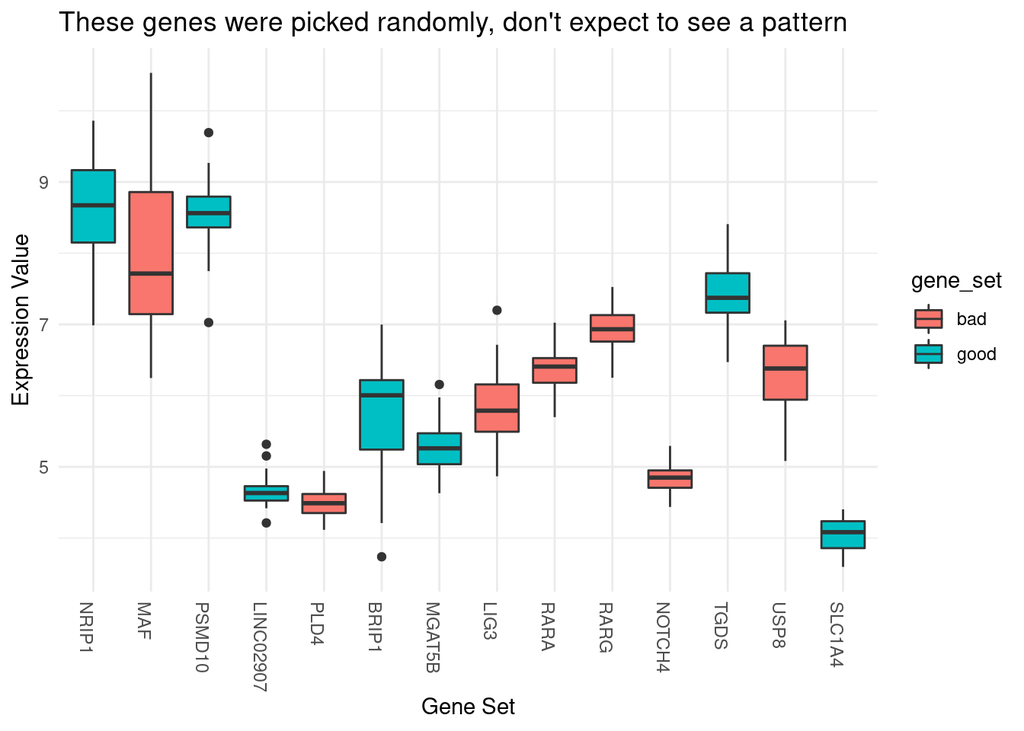

```r
library(ggplot2)

long_format_data$hgnc_symbol <- factor(long_format_data$hgnc_symbol,
                            levels = unique(long_format_data$hgnc_symbol),
                            ordered = TRUE)

ggplot(long_format_data, aes(x = hgnc_symbol, y = value)) +
  geom_boxplot(aes(fill = gene_set)) +
  labs(title = "These genes were picked randomly, don't expect to see a pattern",
       x = "Gene Set",
       y = "Expression Value") +
  theme_minimal() + theme(axis.text.x=element_text(angle = -90, hjust = 0))
```